# Reproducible Research Project 1

Asad Bin Imtiaz

10/22/2020

# Tasks

## Code for reading in the dataset and/or processing the data

```r
setwd("C:/Users/tgdimas1/RStudioProjects/Reproducible Research/Proj1")
data <- read.csv("activity.csv")
summary(data)
```

```
##      steps            date              interval
##  Min.   :  0.00   Length:17568       Min.   :   0.0
##  1st Qu.:  0.00   Class :character   1st Qu.: 588.8
##  Median :  0.00   Mode  :character   Median :1177.5
##  Mean   : 37.38                      Mean   :1177.5
##  3rd Qu.: 12.00                      3rd Qu.:1766.2
##  Max.   :806.00                      Max.   :2355.0
##  NA's   :2304
```

Exploration:

Sturnture:

```r
str(data)
```

```
## 'data.frame':    17568 obs. of  3 variables:
##  $ steps   : int  NA NA NA NA NA NA NA NA NA NA ...
##  $ date    : chr  "2012-10-01" "2012-10-01" "2012-10-01" "2012-10-01" ...
##  $ interval: int  0 5 10 15 20 25 30 35 40 45 ...
```

Summary:

```r
summary(data)
```

```
##      steps            date              interval
##  Min.   :  0.00   Length:17568       Min.   :   0.0
##  1st Qu.:  0.00   Class :character   1st Qu.: 588.8
##  Median :  0.00   Mode  :character   Median :1177.5
##  Mean   : 37.38                      Mean   :1177.5
##  3rd Qu.: 12.00                      3rd Qu.:1766.2
##  Max.   :806.00                      Max.   :2355.0
##  NA's   :2304
```

Dimensions:

```r
dims <- dim(data)
dims
```

```
## [1] 17568     3
```

Field Names:

```r
names(data)
```

```
## [1] "steps"    "date"     "interval"
```

Missing Steps %:

```r
total_data <- dims[[1]]
missing_steps <- sum(is.na(data$steps))/total_data * 100
missing_steps
```

```
## [1] 13.11475
```

Missing dates %:

```r
total_data <- dims[[1]]
missing_steps <- sum(is.na(data$date))/total_data * 100
missing_steps
```

```
## [1] 0
```

Missing intervals %:

```r
total_data <- dims[[1]]
missing_steps <- sum(is.na(data$interval))/total_data * 100
missing_steps
```

```
## [1] 0
```

Sample Dates:

```r
head(data$date)
```

```
## [1] "2012-10-01" "2012-10-01" "2012-10-01" "2012-10-01" "2012-10-01" "2012-10-01"
```

Sample Intervals:

```r
head(data$interval,20)
```

```
##  [1]   0   5  10  15  20  25  30  35  40  45  50  55 100 105 110 115 120 125 130 135
```

## Histogram of the total number of steps taken each day

Histogram

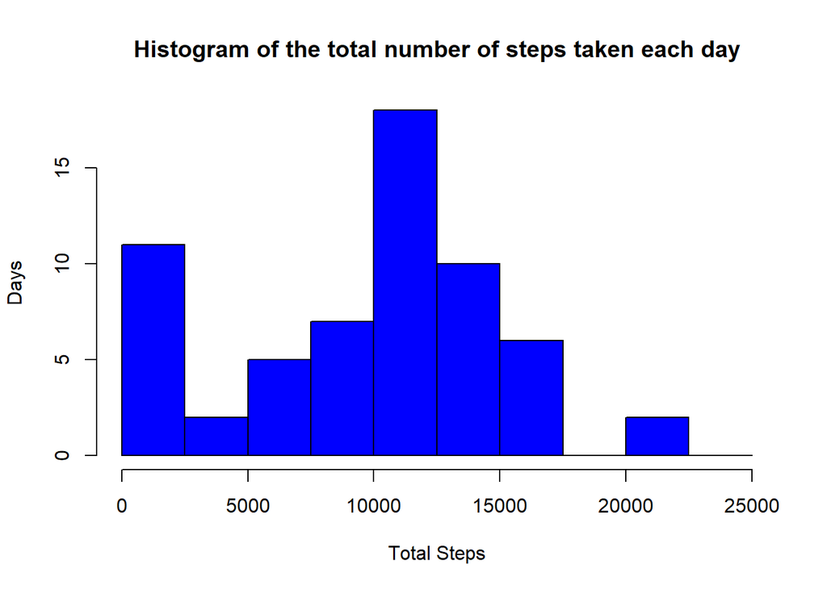

```r
daily_steps <- with(data, aggregate(steps, by = list(date), FUN = sum, na.rm = TRUE))
names(daily_steps) <- c("Date", "Steps")
hist(daily_steps$Steps, breaks = seq(0,25000, by=2500), main="Histogram of the total number of steps taken each day",xlab = "Total Steps", ylab="Days", col="blue")
```

## Mean and median number of steps taken each day

Mean of number of steps taken each day

```r
mean(daily_steps$Steps)
```

```
## [1] 9354.23
```

Median of number of steps taken each day

```r
median(daily_steps$Steps)
```

```
## [1] 10395
```

## Time series plot of the average number of steps taken

Plot of time series plot of the average number of steps taken:

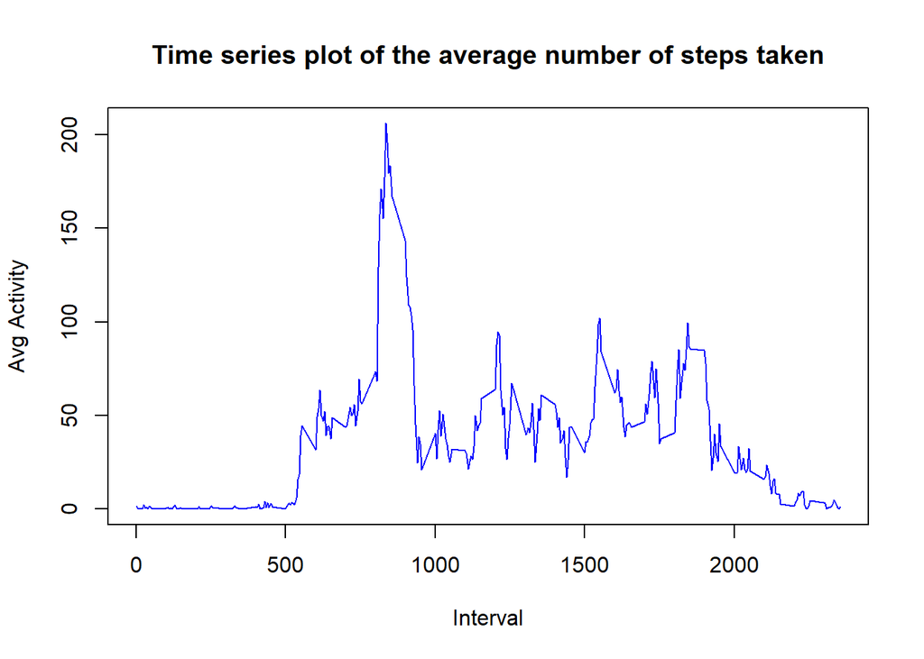

```r
avg_daily_steps <- with(data, aggregate(steps, by = list(interval), FUN = mean, na.rm = TRUE))
names(avg_daily_steps) <- c("Interval", "Activity")
plot(avg_daily_steps$Interval, avg_daily_steps$Activity, main="Time series plot of the average number of steps taken", xlab = "Interval", ylab="Avg Activity", col="blue", type = "l")
```

The 5-minute interval that, on average, contains the maximum number of steps:

```r
avg_daily_steps[which.max(avg_daily_steps$Activity), ]$Interval
```

```
## [1] 835
```

## Code to describe and show a strategy for imputing missing data

There are many missing steps for several days. Number of missing steps:

```r
sum(is.na(data$steps))
```

```
## [1] 2304
```

```r
avg_steps <- avg_daily_steps$Activity[match(data$interval, avg_daily_steps$Interval)]
imputed_data <- transform(data, steps = ifelse(is.na(data$steps), yes = avg_steps, no = data$steps))
sum(is.na(imputed_data$steps))
```

```
## [1] 0
```

### Histogram of the total number of steps taken each day after missing values are imputed

Histogram of the total number of steps taken each day after missing values are imputed:

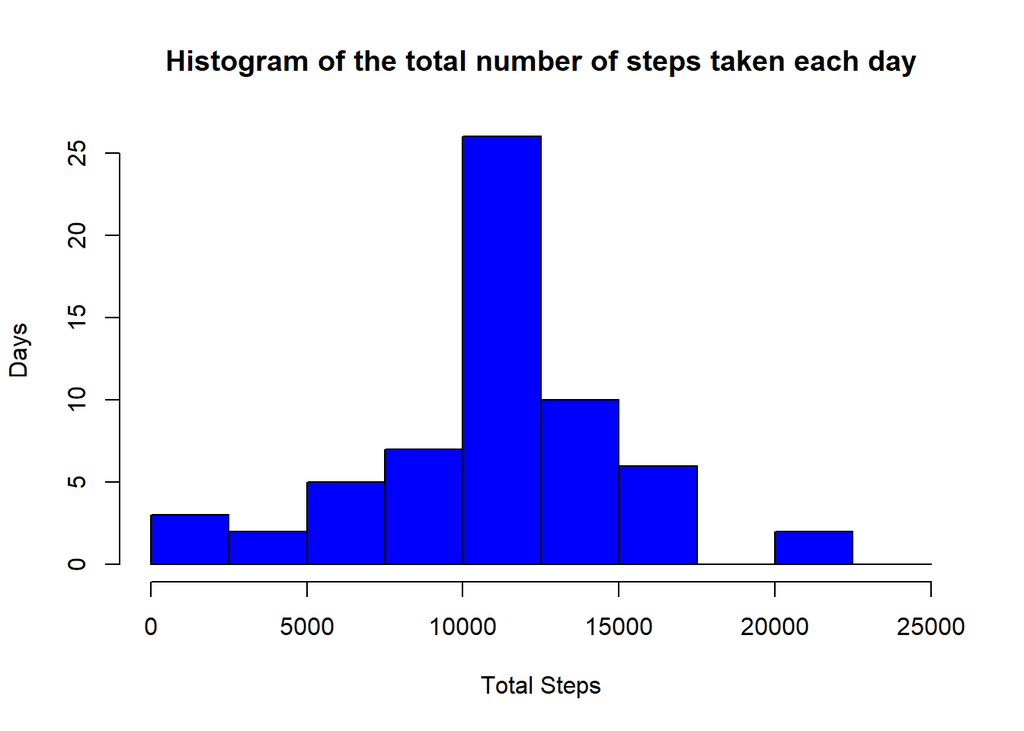

```r
imputed_daily_steps <- with(imputed_data, aggregate(steps, by = list(date), FUN = sum, na.rm = TRUE))
names(imputed_daily_steps) <- c("Date", "Steps")
hist(imputed_daily_steps$Steps, breaks = seq(0,25000, by=2500), main="Histogram of the total number of steps taken each day",xlab = "Total Steps", ylab="Days", col="blue")
```

Mean steps taken each day:

```r
mean(imputed_daily_steps$Steps)
```

```
## [1] 10766.19
```

Median of number of steps taken each day

```r
median(imputed_daily_steps$Steps)
```

```
## [1] 10766.19
```

## Panel plot comparing the average number of steps taken per 5-minute interval across weekdays and weekends

[figure not shown]

```r
imputed_data$date <- as.Date(strptime(imputed_data$date, format="%Y-%m-%d"))
imputed_data$flg_weekday <- ifelse(as.POSIXlt(imputed_data$date)$wday > 5, "Weekday" , "Weekend")
wday_daily_steps <-aggregate(data = imputed_data, steps~interval+flg_weekday, FUN = mean, na.rm = TRUE)
names(wday_daily_steps) <- c("Interval", "Weekday", "Activity")
ggplot(data=wday_daily_steps,aes(y=Activity,x=Interval,color=Weekday))+
  geom_line()+  labs(title = "Average number of steps taken per 5-minute interval across weekdays and weekends", x = "Interval", y = "Ang Steps") +  facet_wrap(~Weekday, ncol = 1, nrow=2)
```